# stock_prediction_data_SBI_analysis

```python
import numpy as np
import pandas as pd
```

```python
df = pd.read_csv("SBIN.csv")
```

```python
df.head(10)
```

|  | Date | Open | High | Low | Close | Adj Close | Volume |
| --- | --- | --- | --- | --- | --- | --- | --- |
| 0 | 01-01-1996 | 18.691147 | 18.978922 | 18.540184 | 18.823240 | 12.409931 | 43733533.0 |
| 1 | 02-01-1996 | 18.894005 | 18.964767 | 17.738192 | 18.224106 | 12.014931 | 56167280.0 |
| 2 | 03-01-1996 | 18.327892 | 18.568489 | 17.643839 | 17.738192 | 11.694577 | 68296318.0 |
| 3 | 04-01-1996 | 17.502312 | 17.832542 | 17.223972 | 17.676863 | 11.654142 | 86073880.0 |
| 4 | 05-01-1996 | 17.738192 | 17.785366 | 17.459852 | 17.577793 | 11.588827 | 76613039.0 |
| 5 | 08-01-1996 | 17.478724 | 17.643839 | 16.922047 | 17.063574 | 11.249807 | 55395172.0 |
| 6 | 09-01-1996 | 16.889023 | 18.681711 | 16.705036 | 17.997660 | 11.865635 | 82057540.0 |
| 7 | 10-01-1996 | 17.407959 | 17.714603 | 17.054138 | 17.172079 | 11.321342 | 54360749.0 |
| 8 | 11-01-1996 | 16.983376 | 17.926895 | 16.983376 | 17.827826 | 11.753670 | 65973105.0 |
| 9 | 12-01-1996 | 17.879719 | 18.233540 | 17.573074 | 17.837261 | 11.759888 | 102152486.0 |

```python
df.tail(10)
```

|  | Date | Open | High | Low | Close | Adj Close | Volume |
| --- | --- | --- | --- | --- | --- | --- | --- |
| 7064 | 29-01-2024 | 619.000000 | 629.500000 | 615.599976 | 622.950012 | 622.950012 | 19572140.0 |
| 7065 | 30-01-2024 | 625.450012 | 633.500000 | 624.200012 | 626.750000 | 626.750000 | 16966577.0 |
| 7066 | 31-01-2024 | 626.400024 | 643.200012 | 622.000000 | 640.500000 | 640.500000 | 23270745.0 |
| 7067 | 01-02-2024 | 642.750000 | 652.950012 | 633.250000 | 647.650024 | 647.650024 | 26587707.0 |
| 7068 | 02-02-2024 | 652.000000 | 660.549988 | 646.700012 | 649.650024 | 649.650024 | 27471811.0 |
| 7069 | 05-02-2024 | 647.099976 | 654.799988 | 638.750000 | 642.950012 | 642.950012 | 28339525.0 |
| 7070 | 06-02-2024 | 644.450012 | 655.000000 | 637.700012 | 650.250000 | 650.250000 | 14079390.0 |
| 7071 | 07-02-2024 | 655.049988 | 677.950012 | 655.000000 | 675.250000 | 675.250000 | 41696232.0 |
| 7072 | 08-02-2024 | 680.400024 | 718.900024 | 678.500000 | 699.549988 | 699.549988 | 74222434.0 |
| 7073 | 09-02-2024 | 703.650024 | 728.349976 | 694.200012 | 725.250000 | 725.250000 | 43235061.0 |

```python
print("Columns:", df.columns)
```

```
Columns: Index(['Date', 'Open', 'High', 'Low', 'Close', 'Adj Close', 'Volume'], dtype='object')
```

```python
print("Data Types:", df.dtypes)
```

```
Data Types: Date          object
Open         float64
High         float64
Low          float64
Close        float64
Adj Close    float64
Volume       float64
dtype: object
```

```python
df.shape
```

```
(7074, 7)
```

```python
print("Size of DataFrame:", df.size)
```

```
Size of DataFrame: 49518
```

```python
print("Numeric Columns:", df.select_dtypes(include=[np.number]).columns)
```

```
Numeric Columns: Index(['Open', 'High', 'Low', 'Close', 'Adj Close', 'Volume'], dtype='object')
```

```python
df.info
```

```
pandas.core.frame.DataFrame.info
def info(verbose: bool | None=None, buf: WriteBuffer[str] | None=None, max_cols: int | None=None, memory_usage: bool | str | None=None, show_counts: bool | None=None) -> None
```

[output not shown]

[output cut: 80 more lines]

[output not shown]

```python
df.describe
```

```
pandas.core.generic.NDFrame.describe
def describe(percentiles=None, include=None, exclude=None) -> Self
```

[output not shown]

[output cut: 178 more lines]

[output not shown]

```python
df['Date'] = pd.to_datetime(df['Date'], dayfirst=True)
```

```python
df.head()
```

|  | Date | Open | High | Low | Close | Adj Close | Volume |
| --- | --- | --- | --- | --- | --- | --- | --- |
| 0 | 1996-01-01 | 18.691147 | 18.978922 | 18.540184 | 18.823240 | 12.409931 | 43733533.0 |
| 1 | 1996-01-02 | 18.894005 | 18.964767 | 17.738192 | 18.224106 | 12.014931 | 56167280.0 |
| 2 | 1996-01-03 | 18.327892 | 18.568489 | 17.643839 | 17.738192 | 11.694577 | 68296318.0 |
| 3 | 1996-01-04 | 17.502312 | 17.832542 | 17.223972 | 17.676863 | 11.654142 | 86073880.0 |
| 4 | 1996-01-05 | 17.738192 | 17.785366 | 17.459852 | 17.577793 | 11.588827 | 76613039.0 |

```python
df.info()
```

```
<class 'pandas.core.frame.DataFrame'>
RangeIndex: 7074 entries, 0 to 7073
Data columns (total 7 columns):
 #   Column     Non-Null Count  Dtype
---  ------     --------------  -----
 0   Date       7074 non-null   datetime64[ns]
 1   Open       7065 non-null   float64
 2   High       7065 non-null   float64
 3   Low        7065 non-null   float64
 4   Close      7065 non-null   float64
 5   Adj Close  7065 non-null   float64
 6   Volume     7065 non-null   float64
dtypes: datetime64[ns](1), float64(6)
memory usage: 387.0 KB
```

```python
import matplotlib.pyplot as plt
import seaborn as sns
```

```python
# Function to create scatter plots
def create_scatter_plot(x_data, y_data, size_data=None, title=None, x_label=None, y_label=None, figsize=(20,10)):
    plt.figure(figsize=figsize)
    sns.scatterplot(x=x_data, y=y_data, size=size_data)
    if title:
        plt.title(title)
    if x_label:
        plt.xlabel(x_label)
    if y_label:
        plt.ylabel(y_label)
    plt.show()
```

```python
# Function to create line plots
def create_line_plot(x_data, y_data, title=None, x_label=None, y_label=None, figsize=(20,10)):
    plt.figure(figsize=figsize)
    sns.lineplot(x=x_data, y=y_data)
    if title:
        plt.title(title)
    if x_label:
        plt.xlabel(x_label)
    if y_label:
        plt.ylabel(y_label)
    plt.show()
```

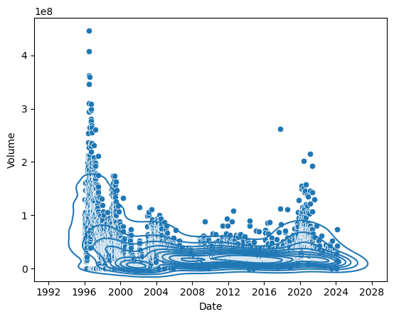

```python
sns.scatterplot(x = df['Date'], y = df['Volume'])
sns.kdeplot(x = df['Date'], y = df['Volume'])
plt.show()
```

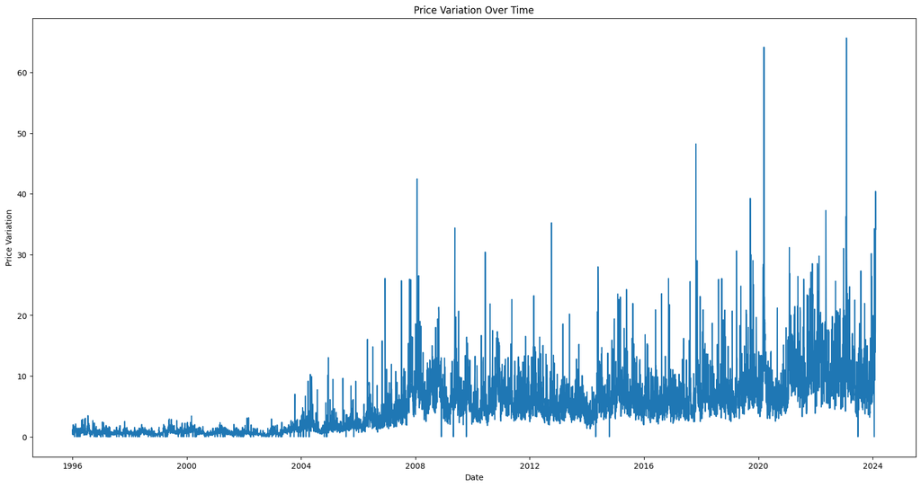

```python
create_line_plot(df['Date'], df['High'] - df['Low'],
                 title='Price Variation Over Time', x_label='Date', y_label='Price Variation')
```

Stable period until 2004: The price variation was relatively low and stable until around 2003-2004, generally staying under 10 units.

2004-2008 increase: Starting from 2004, price variations gradually began to increase, peaking sharply just before the 2008 financial crisis. Some spikes went beyond 40 units.

2008-2020 fluctuations: After the 2008 peak, price variation showed continuous fluctuations with noticeable peaks, though they were more frequent post-2016.

2020 onward: The recent period (2020-2024) shows significant and frequent fluctuations, with peaks reaching 60+ units, possibly influenced by events like the COVID-19 pandemic and other global factors.

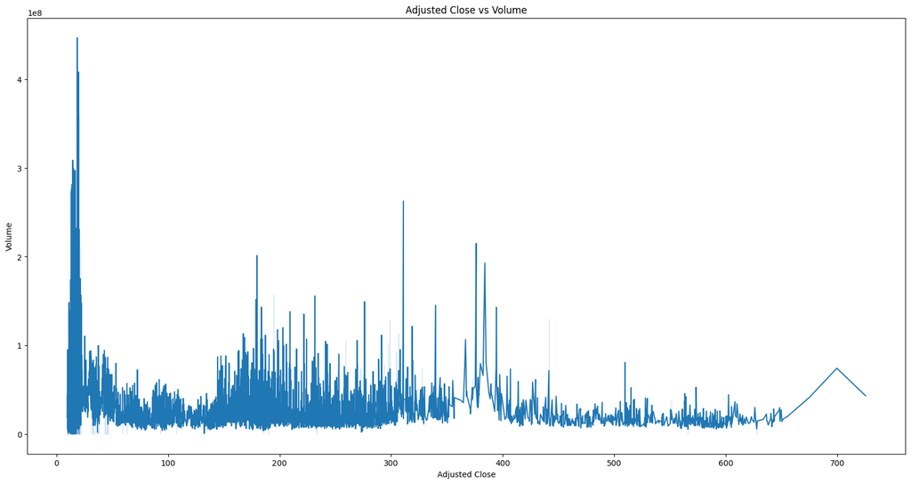

```python
create_line_plot(df['Adj Close'], df['Volume'],
                 title='Adjusted Close vs Volume',
                 x_label='Adjusted Close',
                 y_label='Volume')
```

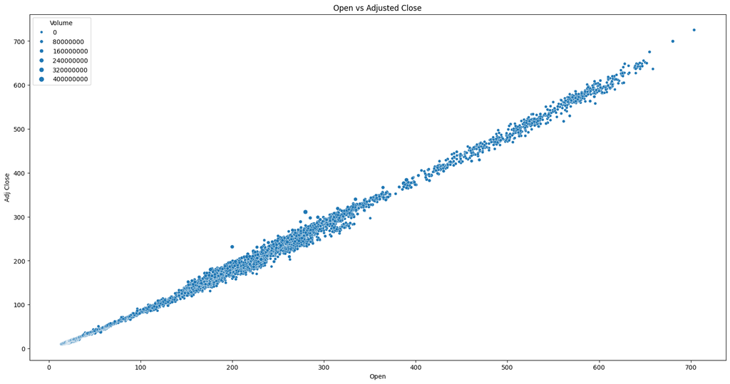

```python
create_scatter_plot(df['Open'], df['Adj Close'], size_data=df['Volume'],
                    title='Open vs Adjusted Close', x_label='Open', y_label='Adj Close')
```

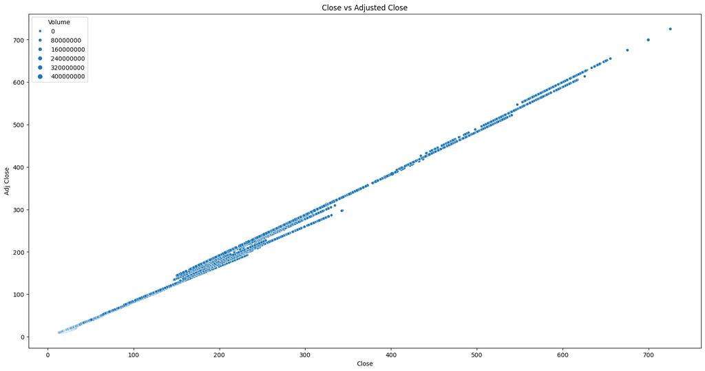

```python
create_scatter_plot(df['Close'], df['Adj Close'], size_data=df['Volume'],
                    title='Close vs Adjusted Close', x_label='Close', y_label='Adj Close')
```

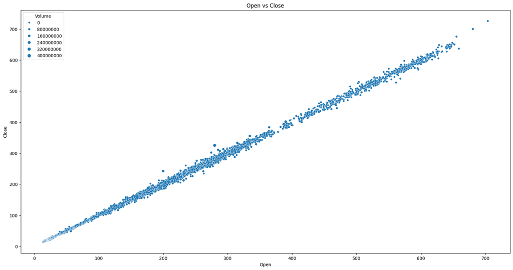

```python
create_scatter_plot(df['Open'], df['Close'], size_data=df['Volume'],
                    title='Open vs Close', x_label='Open', y_label='Close')
```

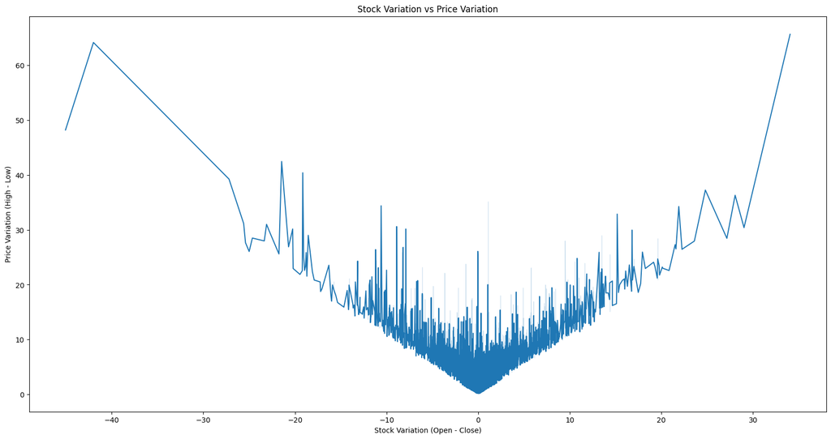

```python
create_line_plot(df['Open'] - df['Close'], df['High'] - df['Low'],
                 title='Stock Variation vs Price Variation',
                 x_label='Stock Variation (Open - Close)',
                 y_label='Price Variation (High - Low)')
```

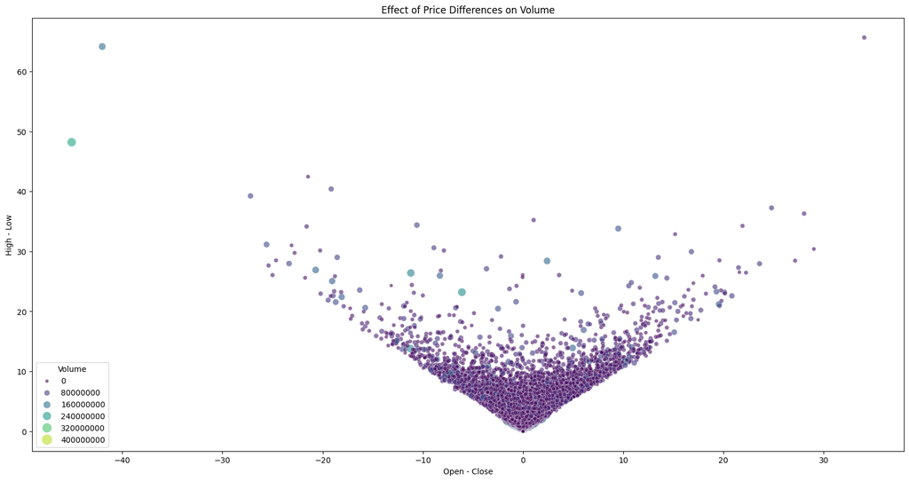

```python
plt.figure(figsize = (20,10))
sns.scatterplot(x=df['Open'] - df['Close'], y=df['High'] - df['Low'], hue=df['Volume'], palette='viridis', size=df['Volume'], sizes=(20, 200), alpha=0.6)
plt.title('Effect of Price Differences on Volume')
plt.xlabel('Open - Close')
plt.ylabel('High - Low')
plt.show()
```

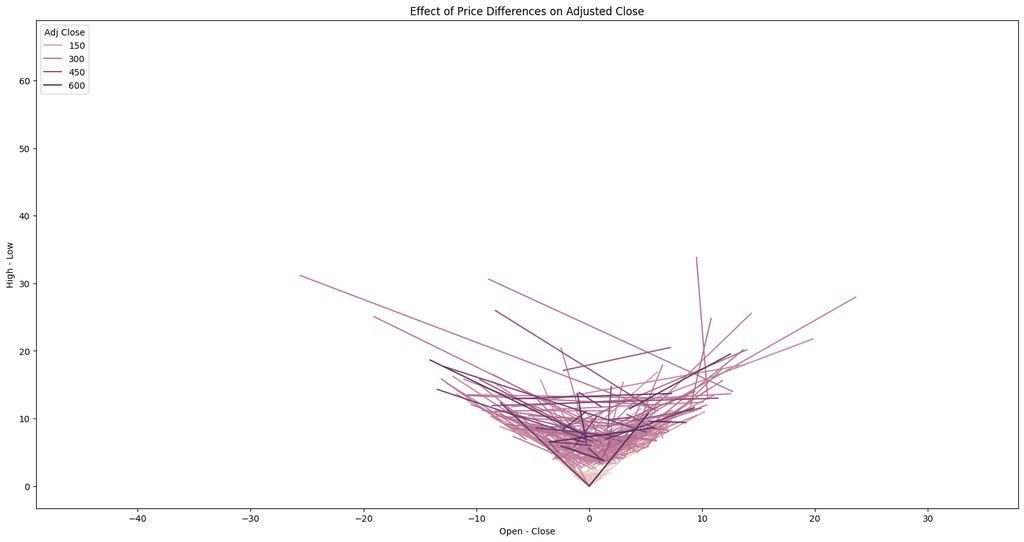

```python
plt.figure(figsize = (20,10))
sns.lineplot(x = df['Open']-df['Close'], y = df['High'] - df['Low'], hue = df['Adj Close'])
plt.title('Effect of Price Differences on Adjusted Close')
plt.xlabel('Open - Close')
plt.ylabel('High - Low')
plt.show()
```

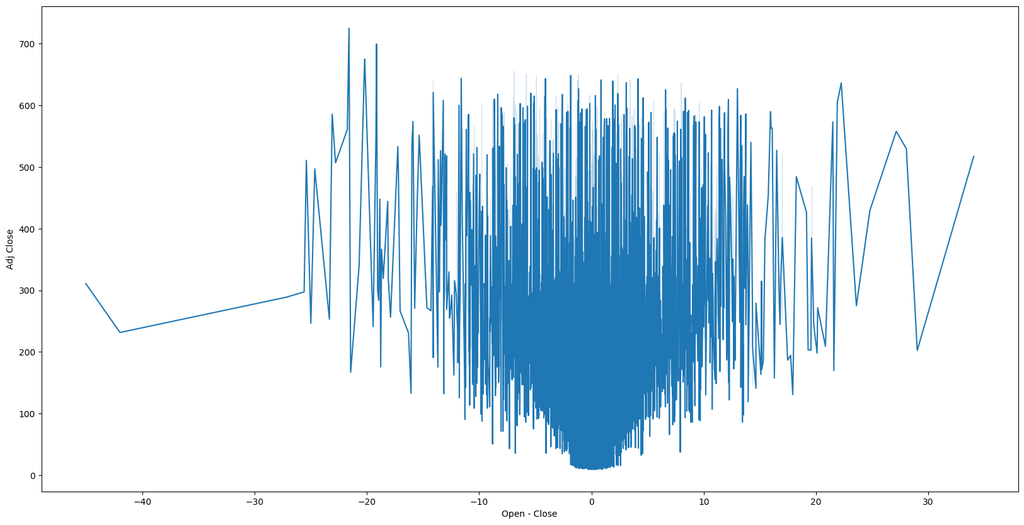

```python
plt.figure(figsize = (20,10))
sns.lineplot(x = df['Open']-df['Close'], y = df['Adj Close'])
plt.xlabel('Open - Close')
plt.show()
```

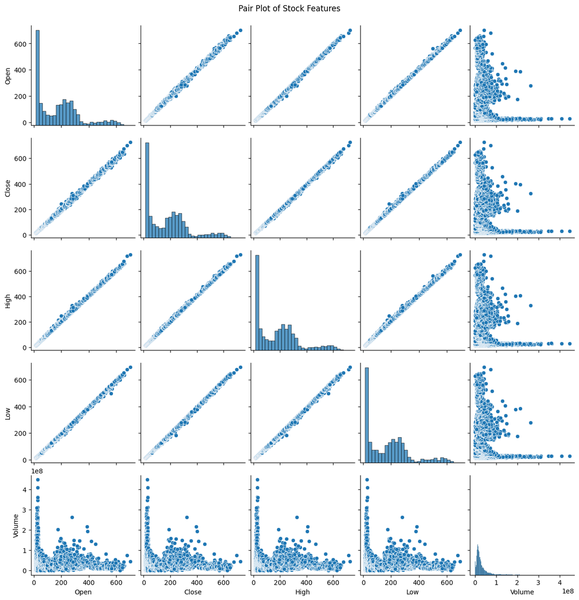

```python
subset = df[['Open', 'Close', 'High', 'Low', 'Volume']]
sns.pairplot(subset)
plt.suptitle('Pair Plot of Stock Features', y=1.02)
plt.show()
```

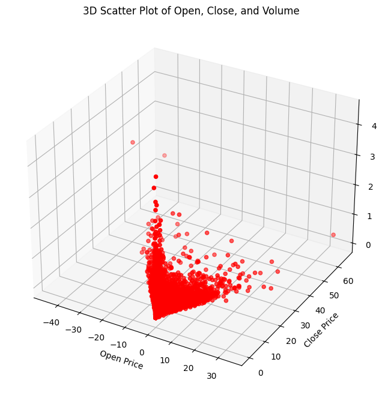

```python
from mpl_toolkits.mplot3d import Axes3D

fig = plt.figure(figsize=(12, 8))
ax = fig.add_subplot(111, projection='3d')
ax.scatter(df['Open']- df['Close'], df['High'] - df['Low'],df['Volume'], c='r', marker='o')
ax.set_xlabel('Open Price')
ax.set_ylabel('Close Price')
ax.set_zlabel('Volume')
plt.title('3D Scatter Plot of Open, Close, and Volume')
plt.show()
```

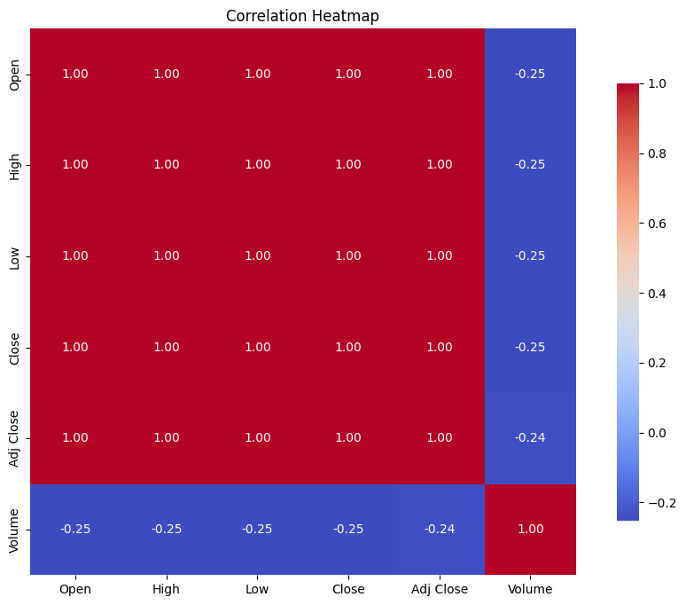

```python
correlation_matrix = df.corr(numeric_only = True)
plt.figure(figsize=(12, 8))
sns.heatmap(correlation_matrix, annot=True, cmap='coolwarm', fmt='.2f', square=True, cbar_kws={"shrink": .8})

plt.title('Correlation Heatmap')
plt.show()
plt.show()
```

The high correlation between 'Open,' 'High,' 'Low,' 'Close,' and 'Adj Close' shows these features are highly interdependent and tend to move together in the same direction. The negative correlation of 'Volume' with price-related features suggests that increased trading volume does not necessarily coincide with an increase in stock prices.